# Lab 4

Kimberly Rodriguez

Stat 364

```r
library(faraway)
```

```r
data(cornnit)
```

```r
attach(cornnit)
```

1. The cornnit data on the relationship between corn yield (bushels per acre) and nitrogen (pounds per acre) fertilizer application were studied in Wisconsin in 1994. Use transformations to find a good model for predicting yield from nitrogen. Use a goodness of fit test to check your model.

```r
names(cornnit)
```

1. 'yield'

2. 'nitrogen'

```r
m1<- lm(yield~nitrogen)
```

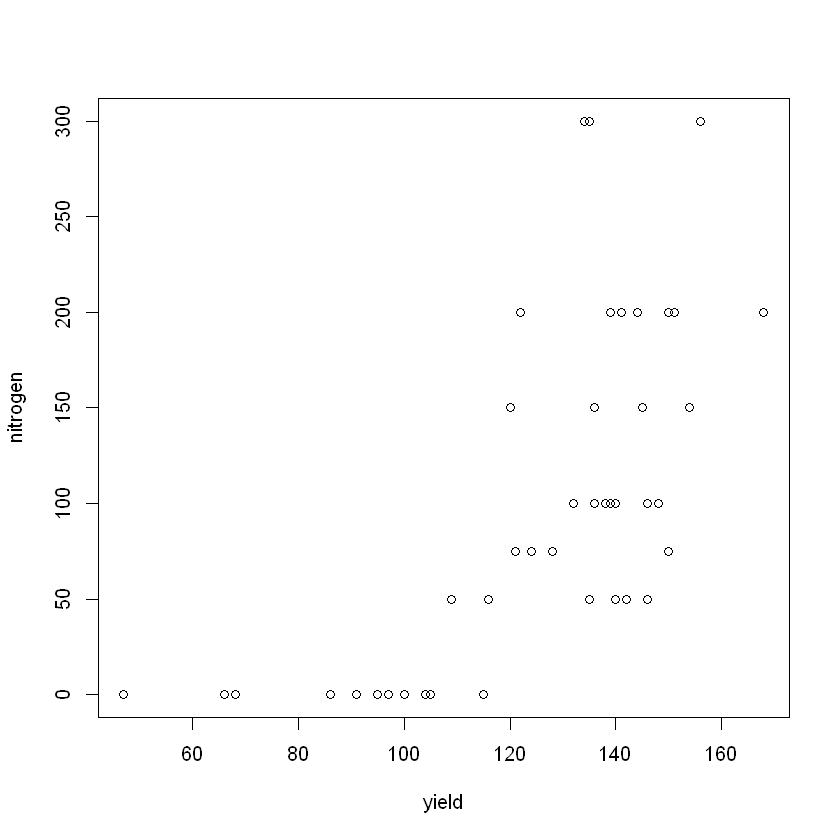

```r
plot(yield,nitrogen)
```

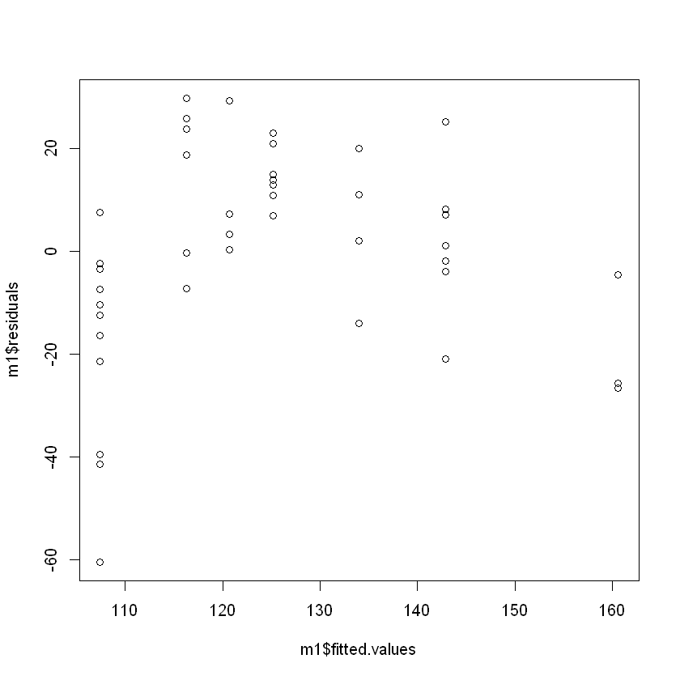

```r
plot(m1$fitted.values, m1$residuals)
```

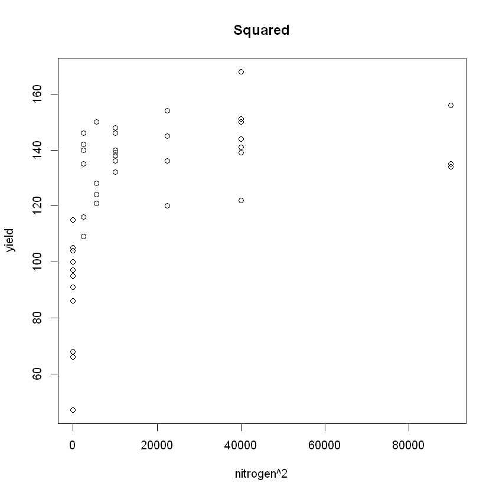

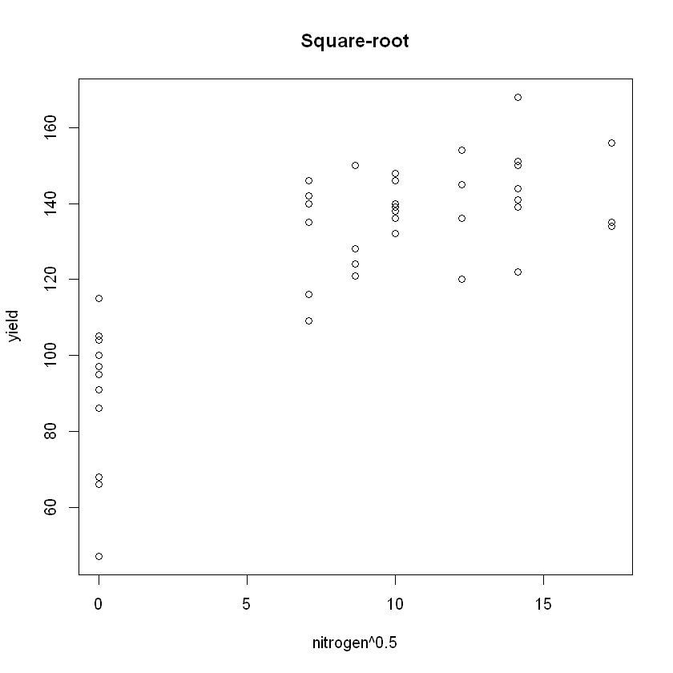

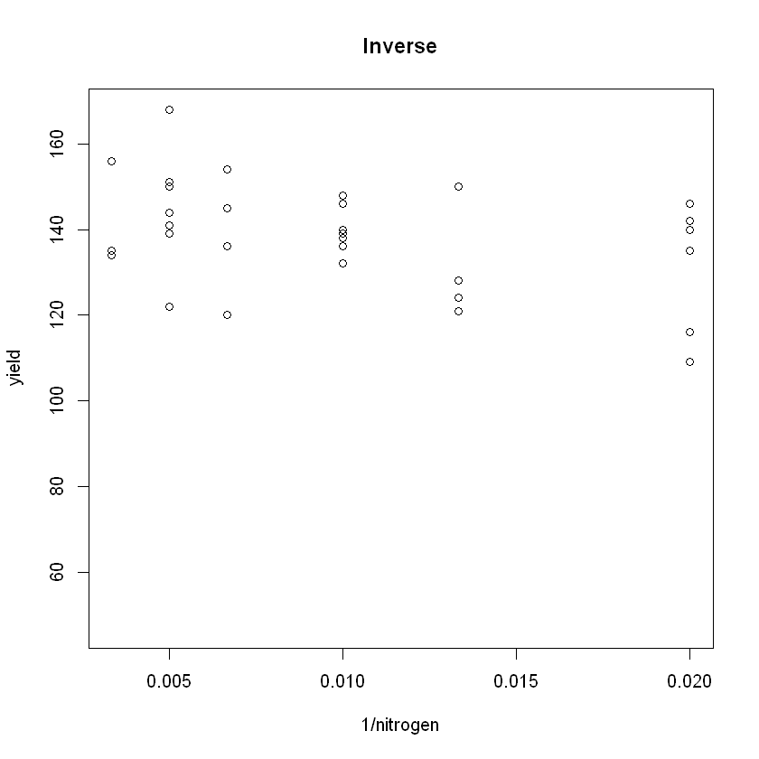

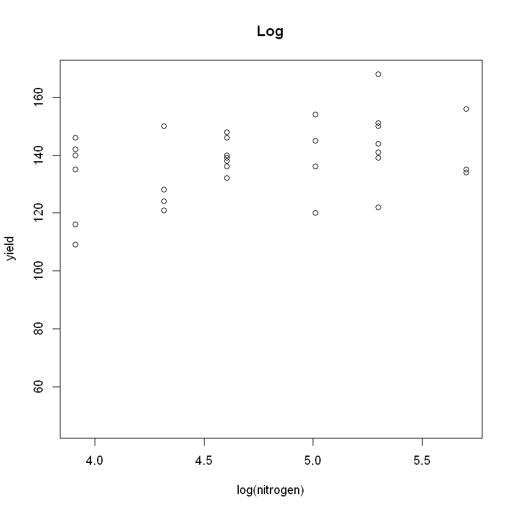

```r
#transformations
plot(nitrogen^2, yield, main="Squared")
plot(nitrogen^.5, yield, main="Square-root")
plot(1/nitrogen, yield, main="Inverse")
plot(log(nitrogen), yield, main="Log")
```

The best plot is the square root one.

```r
root_nitro<- nitrogen^.5
```

```r
m2<- lm(yield~root_nitro)
```

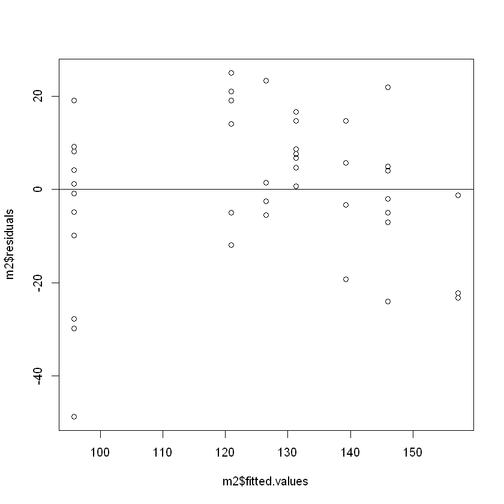

```r
plot(m2$fitted.values, m2$residuals)
abline(h=0)
```

```r
summary(m2)
```

```
Call:
lm(formula = yield ~ root_nitro)

Residuals:
    Min      1Q  Median      3Q     Max
-48.827  -5.912   1.311  10.401  25.087

Coefficients:
            Estimate Std. Error t value Pr(>|t|)
(Intercept)   95.827      4.474  21.416  < 2e-16 ***
root_nitro     3.548      0.440   8.063 4.58e-10 ***
---
Signif. codes:  0 '***' 0.001 '**' 0.01 '*' 0.05 '.' 0.1 ' ' 1

Residual standard error: 16.55 on 42 degrees of freedom
Multiple R-squared:  0.6075,	Adjusted R-squared:  0.5981
F-statistic:    65 on 1 and 42 DF,  p-value: 4.577e-10
```

The R^2 is 0.6075 which means we are close to 1 indicating a better fit. The model explains 60% of the variation in yield. The residual vs fitted plot has some random scatter which is good and there is no clear pattern so that means there is no heteroskedasticity.

4.Using the pressure data, fit a model with pressure as the response and temperature as the predictor using transformations to obtain a good fit.

```r
data(pressure)
```

```r
#for some reason I couldn't attatch the data
m3<-lm(pressure~temperature, data=pressure)
```

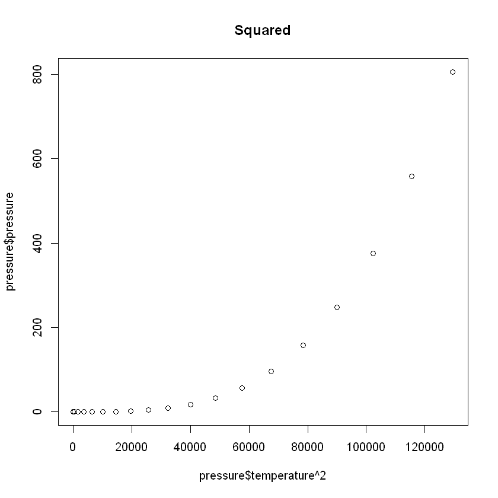

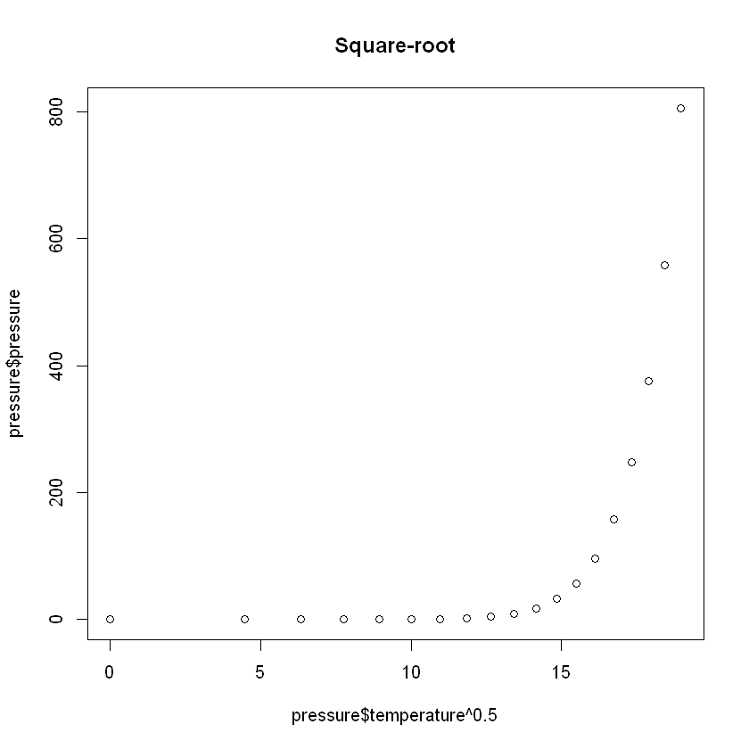

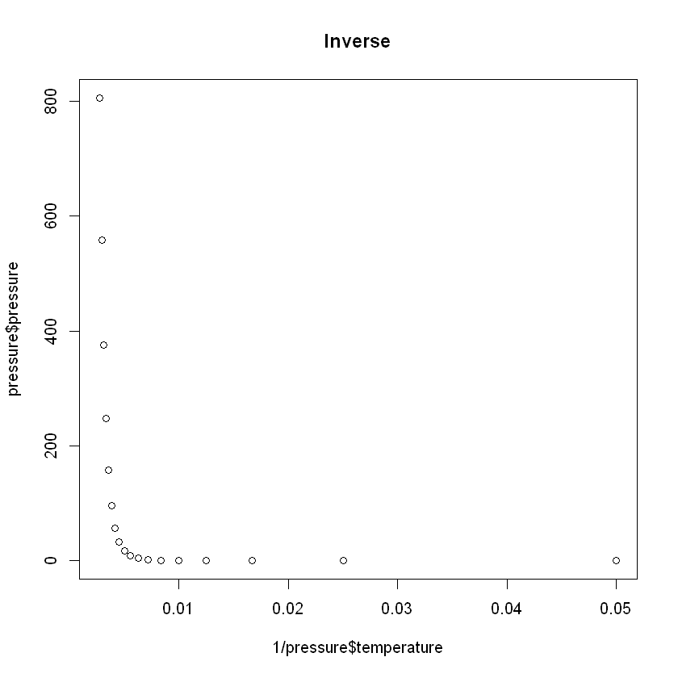

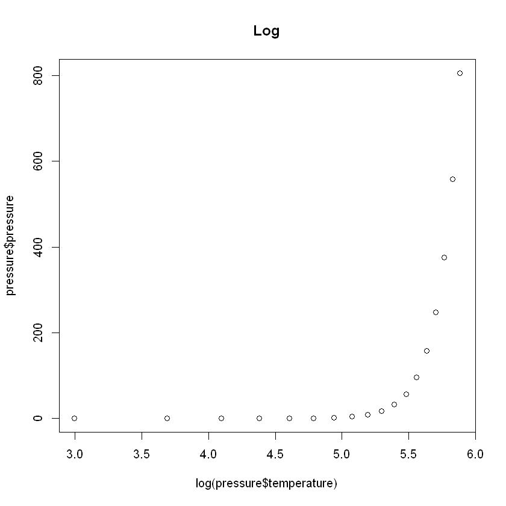

```r
#transformations
plot(pressure$temperature^2, pressure$pressure, main="Squared")
plot(pressure$temperature^.5, pressure$pressure, main="Square-root")
plot(1/pressure$temperature, pressure$pressure, main="Inverse")
plot(log(pressure$temperature), pressure$pressure, main="Log")
```

The best fit would probably be squared since it's a positive slope and it's the most linear out of all of them although there is curvature.

```r
pressure_filtered <- pressure[!is.na(pressure$temperature) & pressure$temperature > 0, ]
```

```r
squared<- pressure_filtered$temperatur^2
```

```r
m20<- lm(pressure_filtered$pressure~squared)
```

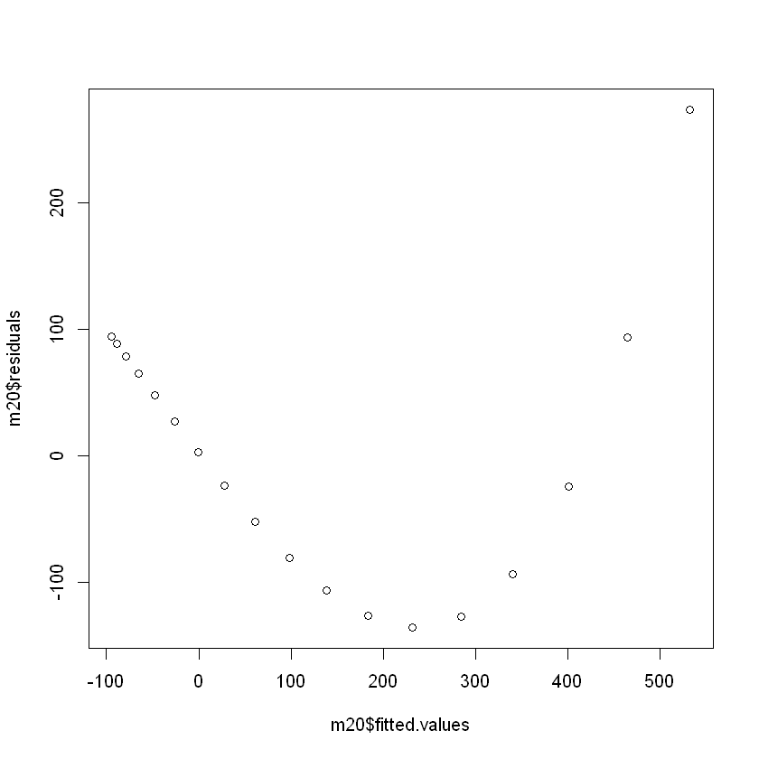

```r
plot(m20$fitted.values, m20$residuals)
```

```r
summary(m20)
```

```
Call:
lm(formula = pressure_filtered$pressure ~ squared)

Residuals:
    Min      1Q  Median      3Q     Max
-135.80  -90.24  -10.53   75.25  273.50

Coefficients:
              Estimate Std. Error t value Pr(>|t|)
(Intercept) -9.606e+01  3.972e+01  -2.418   0.0279 *
squared      4.850e-03  6.408e-04   7.569 1.13e-06 ***
---
Signif. codes:  0 '***' 0.001 '**' 0.01 '*' 0.05 '.' 0.1 ' ' 1

Residual standard error: 110.3 on 16 degrees of freedom
Multiple R-squared:  0.7817,	Adjusted R-squared:  0.7681
F-statistic: 57.29 on 1 and 16 DF,  p-value: 1.129e-06
```

```r
shapiro.test(residuals(m20))
```

```
	Shapiro-Wilk normality test

data:  residuals(m20)
W = 0.92184, p-value = 0.1394
```

There is a clear pattern in the plot that has some curvature indicating heteroskedasticity. For the Shapiro-wilk test we fail to reject the null hypothesis since the p-value is larger than 0.05. The R^2 is good since it's close to the value 1. The model explains 78.17% of the variation in pressure.

1. Use transformations to find a good model for volume in terms of girth and height using the trees data.

```r
data(trees)
```

```r
attach(trees)
```

```r
summary(trees)
```

```
     Girth           Height       Volume
 Min.   : 8.30   Min.   :63   Min.   :10.20
 1st Qu.:11.05   1st Qu.:72   1st Qu.:19.40
 Median :12.90   Median :76   Median :24.20
 Mean   :13.25   Mean   :76   Mean   :30.17
 3rd Qu.:15.25   3rd Qu.:80   3rd Qu.:37.30
 Max.   :20.60   Max.   :87   Max.   :77.00
```

```r
mod2<-lm(Volume~Girth+Height)
```

```r
combined<-Girth+Height
```

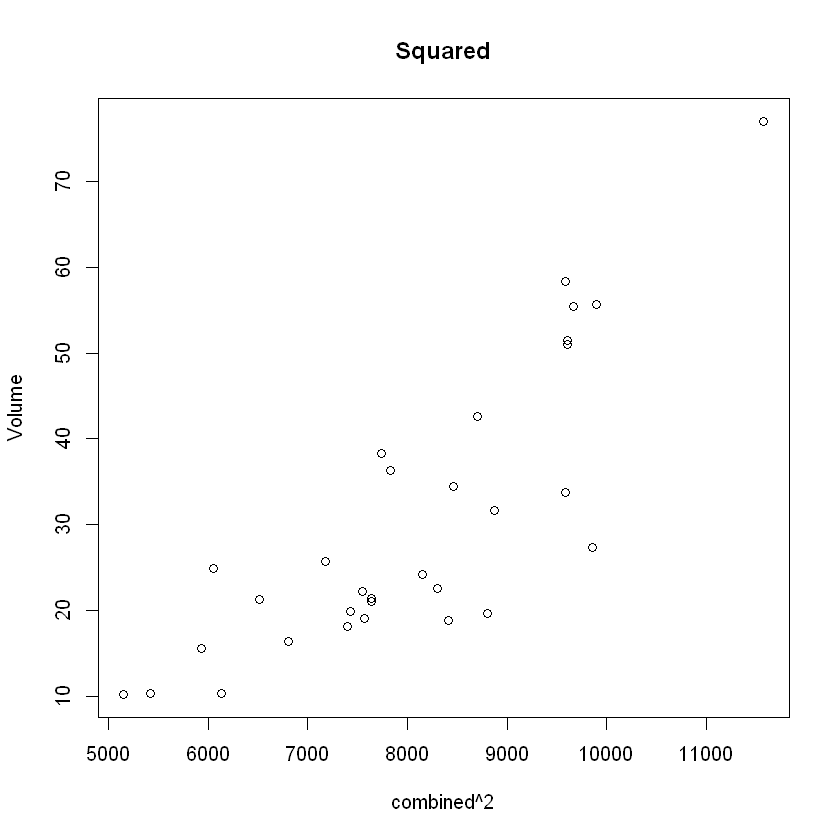

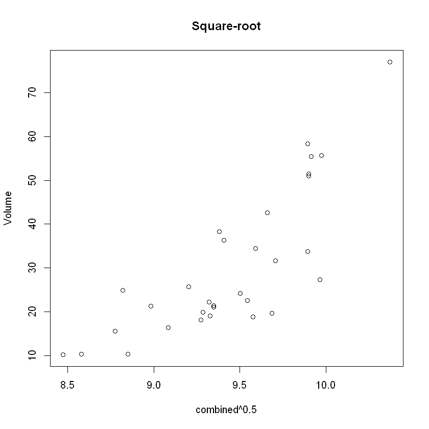

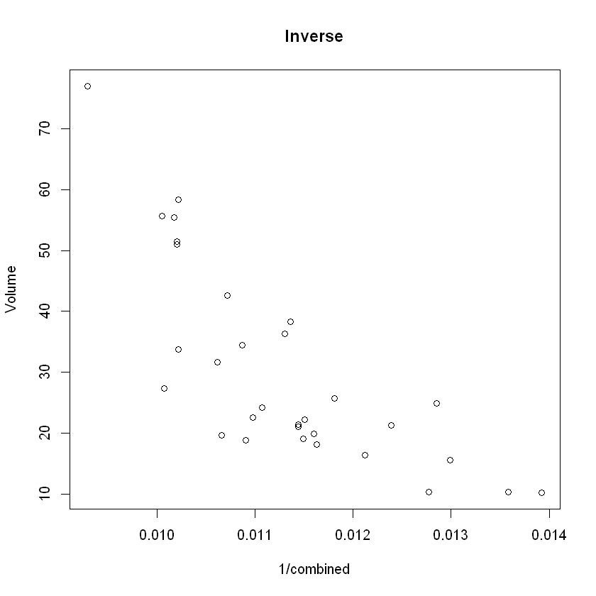

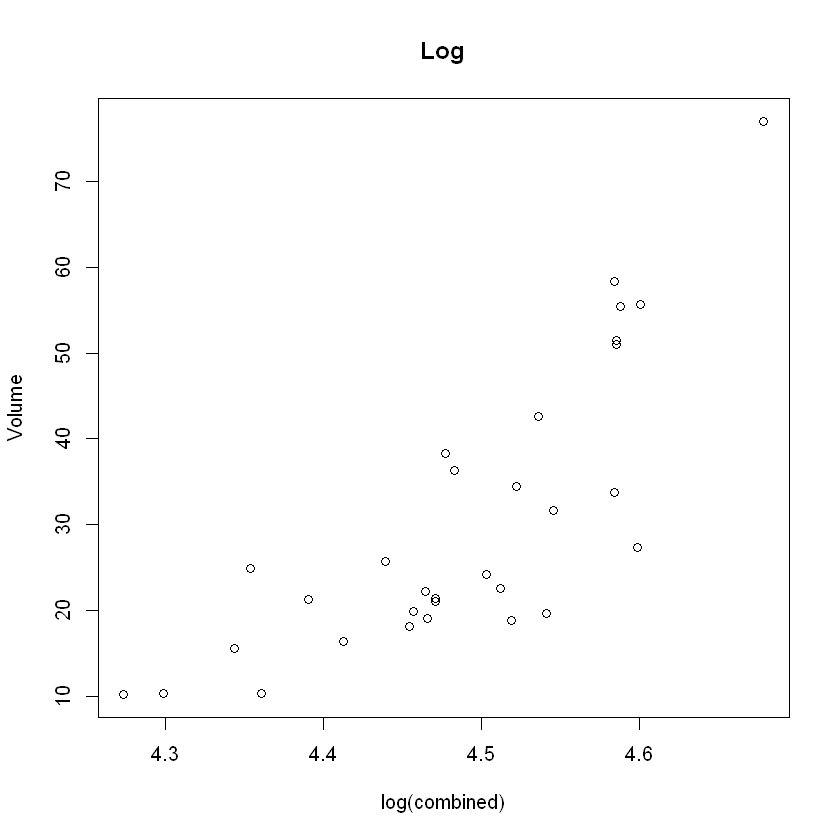

```r
plot(combined^2, Volume, main="Squared")
plot(combined^.5, Volume, main="Square-root")
plot(1/combined, Volume, main="Inverse")
plot(log(combined), Volume, main="Log")
```

```r
mod3<-lm(Volume~combined^2)
```

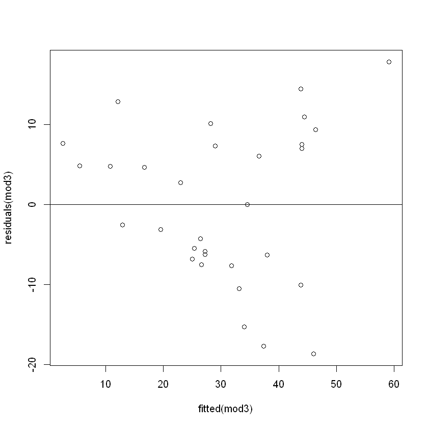

```r
plot(fitted(mod3), residuals(mod3))
abline(h=0)
```

```r
summary(mod3)
```

```
Call:
lm(formula = Volume ~ combined^2)

Residuals:
     Min       1Q   Median       3Q      Max
-18.6566  -6.5669  -0.0196   7.4048  17.8260

Coefficients:
             Estimate Std. Error t value Pr(>|t|)
(Intercept) -110.8779    18.9523  -5.850 2.40e-06 ***
combined       1.5804     0.2114   7.474 3.08e-08 ***
---
Signif. codes:  0 '***' 0.001 '**' 0.01 '*' 0.05 '.' 0.1 ' ' 1

Residual standard error: 9.773 on 29 degrees of freedom
Multiple R-squared:  0.6583,	Adjusted R-squared:  0.6465
F-statistic: 55.87 on 1 and 29 DF,  p-value: 3.082e-08
```

Check for normality:

```r
shapiro.test(residuals(mod3))
```

```
	Shapiro-Wilk normality test

data:  residuals(mod3)
W = 0.96655, p-value = 0.4294
```

**Rubber band data**

```r
setwd('C:/Users/maste/OneDrive/Desktop/Stat 364')
```

```r
band<-read.csv("band_length.csv")
```

```r
View(band)
```

A data.frame: 11 × 3

| dice <int> | red <dbl> | yellow <dbl> |
| --- | --- | --- |
| 0 | 2.20 | 1.25 |
| 4 | 2.25 | 1.25 |
| 8 | 2.25 | 1.25 |
| 16 | 2.50 | 1.50 |
| 24 | 2.70 | 1.75 |
| 32 | 2.80 | 1.80 |
| 40 | 3.25 | 2.00 |
| 48 | 3.90 | 2.25 |
| 56 | 4.45 | 2.70 |
| 64 | 4.60 | 2.90 |
| 72 | 5.00 | 3.00 |

**a) Graph the data for each rubber band. Which shows the most curvature?**

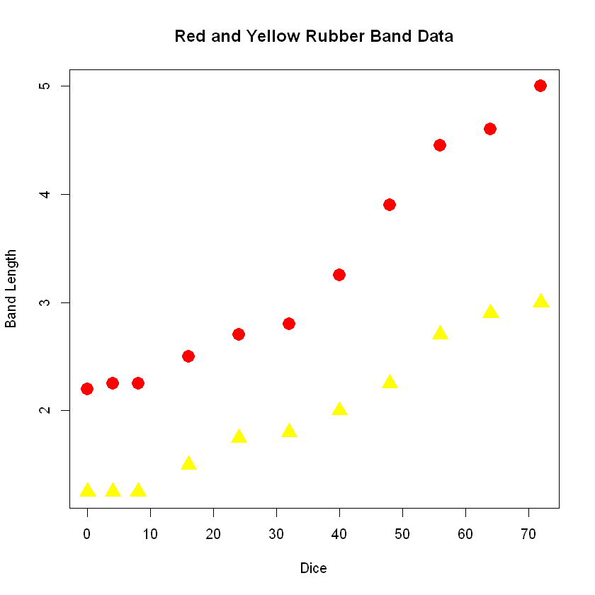

```r
y_range <- range(c(band$red, band$yellow))

plot(band$dice, band$red, col="red", pch=16, cex=2, xlab="Dice", ylab="Band Length", main="Red and Yellow Rubber Band Data", ylim=y_range)
points(band$dice, band$yellow, col="yellow", pch=17, cex=2)
```

They both show curvature but, it'd say the red rubber band shows more.

**b) Fit a model for the rubber band that exhibits the most curvature. Assess Normality of residuals and homoskedasticity for a model using the raw data, and then for a model using a transformation on weight to correct the curve.**

```r
mod1<-lm(red~dice,data=band)
```

```r
shapiro.test(residuals(mod1))
```

```
	Shapiro-Wilk normality test

data:  residuals(mod1)
W = 0.95071, p-value = 0.653
```

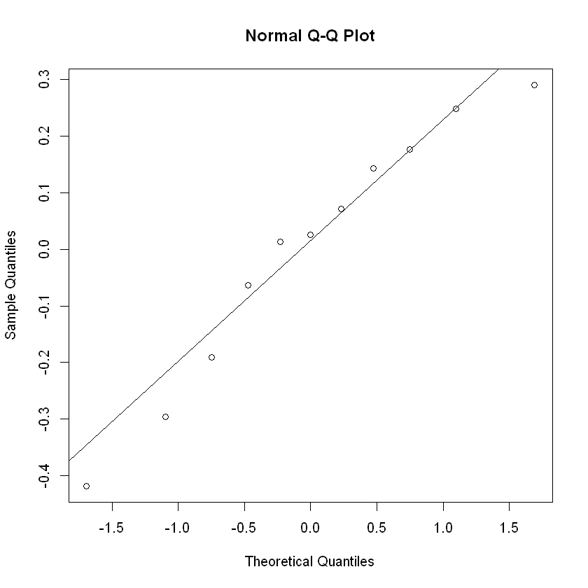

```r
qqnorm(mod1$residuals)
qqline(mod1$residuals)
```

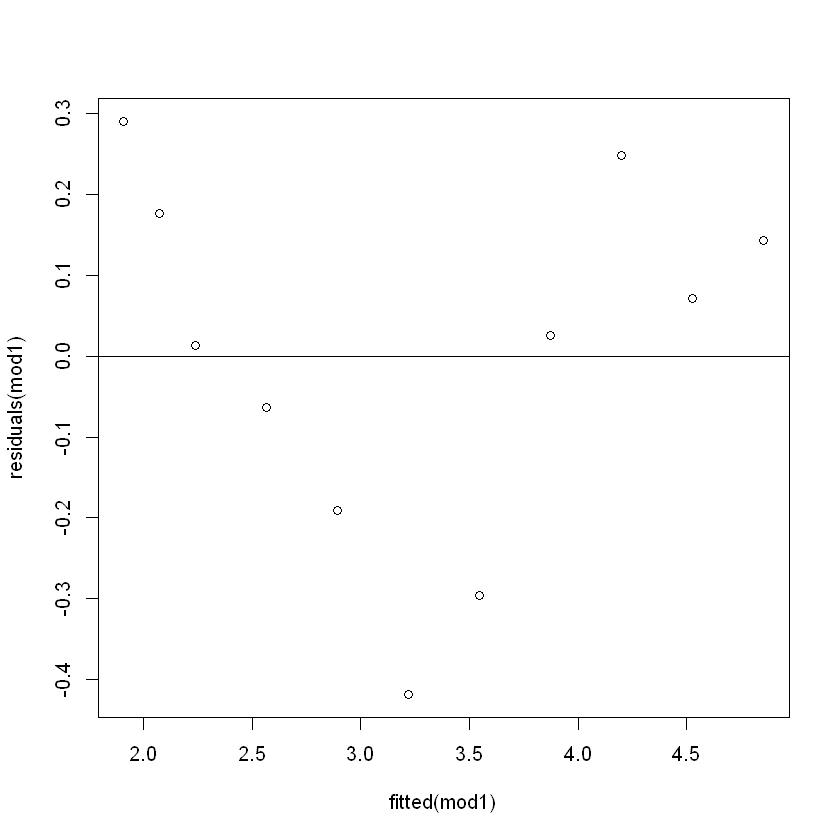

```r
plot(fitted(mod1),residuals(mod1))
abline(h=0)
```

Since the p-value is larger than 0.05 we fail to reject the null hypothesis. The qqplot confirms that there is normality. There appears to be a pattern in the fitted vs residuals plot so that means there is heteroskedasticity.

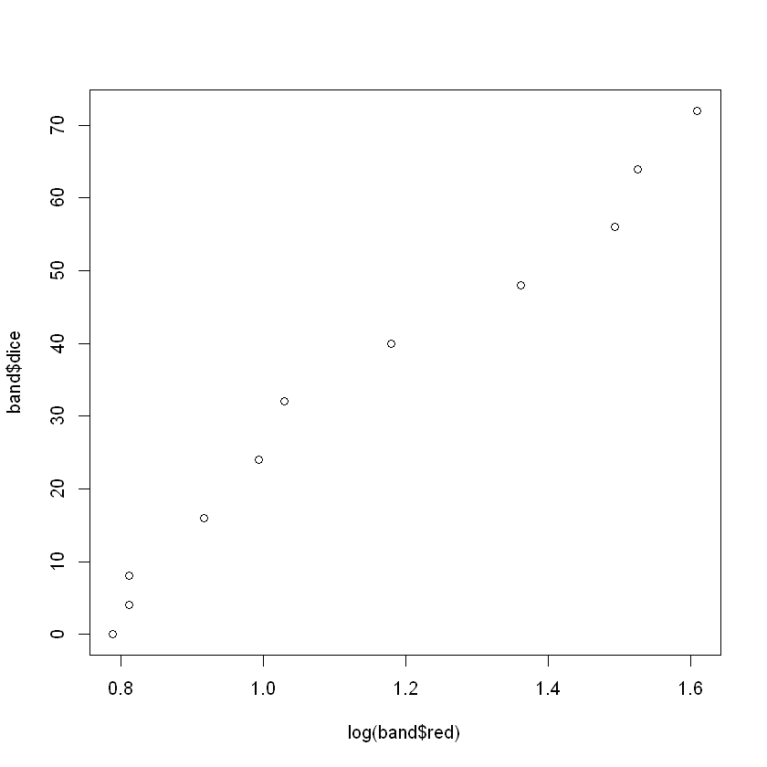

```r
plot(log(band$red), band$dice)
```

**c) Produce a 90% prediction interval estimate for how much your rubber band should stretch next time it's weighed down with a weight equal to the 80th percentile of your measured weights. Show the code used, the interval produced, and interpret it in a complete sentence or two.**

```r
eighty <- quantile(band$dice, 0.8)
```

```r
new_data <- data.frame(dice = eighty)
prediction <- predict(mod1, newdata = new_data, interval = "prediction", level = 0.90)
```

```r
eighty
```

**80%:** 56

```r
prediction
```

A matrix: 1 × 3 of type dbl

|  | fit | lwr | upr |
| --- | --- | --- | --- |
| 80% | 4.201393 | 3.728956 | 4.67383 |

The 80th percentile of weights is approximately 56. The rubber band will stratch 4.201393 units. With 90% confidence the rubber band will stretch between 3.728956 and 4.67383 units.

**d) Produce a 95% confidence interval for the slope of your transformed weight. Interpret what this interval means.**

```r
mod_log <-lm(log(band$red)~dice, data=band)

confint(mod_log, level = 0.95)
```

A matrix: 2 × 2 of type dbl

|  | 2.5 % | 97.5 % |
| --- | --- | --- |
| (Intercept) | 0.66977509 | 0.79006880 |
| dice | 0.01085427 | 0.01380709 |

The 95% confidence interval for the slope is [0.01085427, 0.01380709].

**e) Create a plot in R showing the raw data with an overlaid curve that corresponds to your curve-corrected fit. There are a few ways you can do this - provide the plot and the code please.**

```r
s<-seq(min(band$dice), max(band$dice))
s2<-s^2
predval<-mod_log$coefficients[1]+(mod_log$coefficients[2]*s2)
```

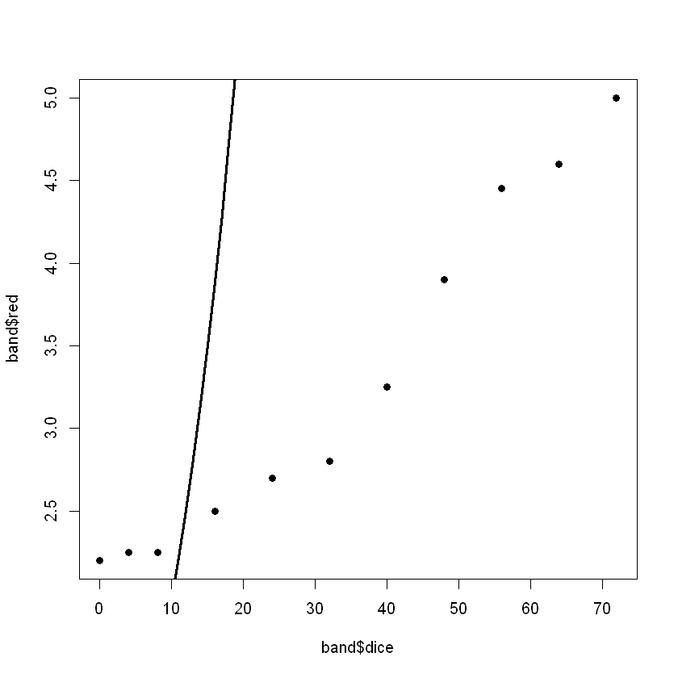

```r
plot(band$dice, band$red, pch = 16)
lines(s, predval, lwd = 3)
```